# Online Retail - Unsupervised Learning

Snehal Agrawal, Dikshita Barman, Huong Huynh, Zhu Wen, Saurav Gupta

## Introduction

Online retail is a transactional data set which contains all the transactions occurring between 01/12/2010 and 09/12/2011 for a UK-based and registered non-store online retail. The company mainly sells unique all-occasion gifts. Many customers of the company are wholesalers.

We aim to segment the Customers based on RFM(Recency, Frequency, Monetary) so that the company can target its customers efficiently.

*Recency* — How recently did the customer purchase? It means the number of days since a customer made the last purchase.  
*Frequency* — How often do they purchase in a given period. So we can understand this value as for how often or how many a customer used the product of a company. The bigger the value is, the more engaged the customers are.  
*Monetary* — How much do they spend? It is the total amount of money a customer spent in a given period. Therefore big spenders will be differentiated with other customers such as MVP or VIP.

We have taken the dataset from Kaggle, data source link [Online Retail](https://www.kaggle.com/hellbuoy/online-retail-k-means-hierarchical-clustering).

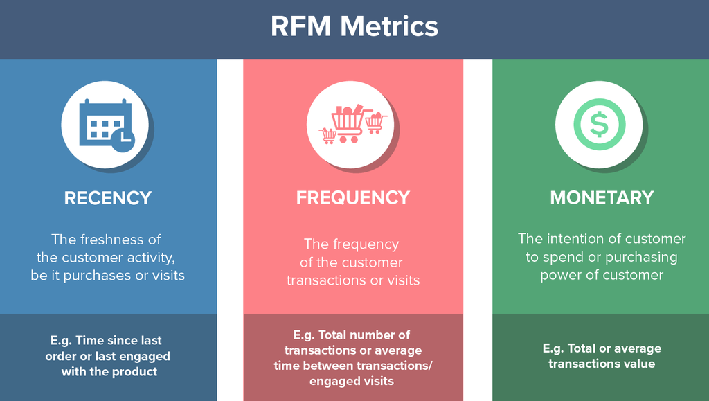

RFM

## Understanding the Data

**Data Import**

```r
set.seed(123456)
retail <- read.csv("~/OnlineRetail.csv")
dim(retail)
```

```
## [1] 541909      8
```

We have 541909 observations and 8 columns

**Packages Required**

```r
library(rmarkdown)
library(DT)
library(ggplot2)
library(tidyverse)
library(grid)
library(knitr)
library(dplyr)
library(lubridate)
#require(devtools)
#install_github("Displayr/flipTime")
library(flipTime)
library(factoextra)
library(gridExtra)
library(fpc)
library(tidyr)
library(cluster)
library(clValid)
library(dendextend)
```

**Structure of the data**

```r
str(retail)
```

```
## 'data.frame':    541909 obs. of  8 variables:
##  $ InvoiceNo  : Factor w/ 25900 levels "536365","536366",..: 1 1 1 1 1 1 1 2 2 3 ...
##  $ StockCode  : Factor w/ 4070 levels "10002","10080",..: 3538 2795 3045 2986 2985 1663 801 1548 1547 3306 ...
##  $ Description: Factor w/ 4224 levels ""," 4 PURPLE FLOCK DINNER CANDLES",..: 4027 4035 932 1959 2980 3235 1573 1698 1695 259 ...
##  $ Quantity   : int  6 6 8 6 6 2 6 6 6 32 ...
##  $ InvoiceDate: Factor w/ 23260 levels "01-02-2011 08:23",..: 607 607 607 607 607 607 607 608 608 609 ...
##  $ UnitPrice  : num  2.55 3.39 2.75 3.39 3.39 7.65 4.25 1.85 1.85 1.69 ...
##  $ CustomerID : int  17850 17850 17850 17850 17850 17850 17850 17850 17850 13047 ...
##  $ Country    : Factor w/ 38 levels "Australia","Austria",..: 36 36 36 36 36 36 36 36 36 36 ...
```

**Data Dictionary**

| Variable | Type | Description |
| --- | --- | --- |
| InvoiceNo | factor | a 6-digit integral number uniquely assigned to each transaction |
| StockCode | factor | a 5-digit integral number uniquely assigned to each distinct product |
| Description | factor | Product Name |
| Quantity | int | The quantities of each product (item) per transaction |
| InvoiceDate | factor | the day and time when each transaction was generated |
| UnitPrice | number | Product price per unit in sterling |
| CustomerID | integer | a 5-digit integral number uniquely assigned to each customer |
| Country | factor | the name of the country where each customer resides |

## Data Cleansing and Preparation

Missing and null values:

```r
colSums(is.na(retail))
```

```
##   InvoiceNo   StockCode Description    Quantity InvoiceDate   UnitPrice
##           0           0           0           0           0           0
##  CustomerID     Country
##      135080           0
```

```r
any(is.null(retail))
```

```
## [1] FALSE
```

There are 135080 missing values and no null values in the dataset. But CustomerID is a key attribute in determining the RFM so we will omit the missing rows from our dataset.

```r
retail = na.omit(retail)
dim(retail)
```

```
## [1] 406829      8
```

After removing the missing values, we have 406829 observations in the dataset.

Replacing negative with NA Values:

```r
retail <- mutate(retail, Quantity = replace(Quantity, Quantity <= 0, NA),
         UnitPrice = replace(UnitPrice, UnitPrice <= 0, NA))
```

Duplicate Values:

```r
dim(unique(retail))[1]
```

```
## [1] 401574
```

**Data Preparation**

In order to perform analysis, we need to split the InvoiceDate into Day, Month, Year and Hour. Hence, we will first convert it to character and split the InvoiceDate records into weekOfDay, hourOfDay, month and year.

```r
retail$InvoiceDate <- as.character(retail$InvoiceDate)
```

```r
# separate date and time components of invoice date
retail$date <- sapply(retail$InvoiceDate, FUN = function(x) {strsplit(x, split = '[ ]')[[1]][1]})
retail$time <- sapply(retail$InvoiceDate, FUN = function(x) {strsplit(x, split = '[ ]')[[1]][2]})
# create month, year and hour of day variables
retail$month <- sapply(retail$date, FUN = function(x) {strsplit(x, split = '[-]')[[1]][2]})
retail$year <- sapply(retail$date, FUN = function(x) {strsplit(x, split = '[-]')[[1]][3]})
retail$hourOfDay <- sapply(retail$time, FUN = function(x) {strsplit(x, split = '[:]')[[1]][1]})
```

We will convert the date variable to the appopriate class so we can do a bit more with it and create a column of TotalSales and dayOfWeek.

```r
retail$InvoiceDate <- AsDateTime(retail$InvoiceDate)
retail = mutate(retail, TotalSales = Quantity*UnitPrice)
retail$dayOfWeek <- wday(retail$InvoiceDate,label = TRUE)
```

That’s given us a good dataframe to start performing some summary analyses. But before we move on to getting involved with product and customer segmentation, we’ll turn the appropriate variables into factors:

```r
retail$Country <- as.factor(retail$Country)
retail$month <- as.factor(retail$month)
retail$year <- as.factor(retail$year)
levels(retail$year) <- c(2010,2011)
hourOfDay <- as.factor(retail$hourOfDay)
retail$dayOfWeek <- as.factor(retail$dayOfWeek)
```

**Table View of the Data**:

```r
datatable(head(retail,100),extensions = 'FixedColumns', options = list(scrollX = TRUE, scrollY = "400px",fixedColumns = TRUE))
```

|  | InvoiceNo | StockCode | Description | Quantity | InvoiceDate | UnitPrice | CustomerID | Country | date | time | month | year | hourOfDay | TotalSales | dayOfWeek |
| --- | --- | --- | --- | --- | --- | --- | --- | --- | --- | --- | --- | --- | --- | --- | --- |
| 1 | 536365 | 85123A | WHITE HANGING HEART T-LIGHT HOLDER | 6 | 2010-12-01T08:26:00Z | 2.55 | 17850 | United Kingdom | 01-12-2010 | 08:26 | 12 | 2010 | 08 | 15.3 | Wed |
| 2 | 536365 | 71053 | WHITE METAL LANTERN | 6 | 2010-12-01T08:26:00Z | 3.39 | 17850 | United Kingdom | 01-12-2010 | 08:26 | 12 | 2010 | 08 | 20.34 | Wed |
| 3 | 536365 | 84406B | CREAM CUPID HEARTS COAT HANGER | 8 | 2010-12-01T08:26:00Z | 2.75 | 17850 | United Kingdom | 01-12-2010 | 08:26 | 12 | 2010 | 08 | 22 | Wed |
| 4 | 536365 | 84029G | KNITTED UNION FLAG HOT WATER BOTTLE | 6 | 2010-12-01T08:26:00Z | 3.39 | 17850 | United Kingdom | 01-12-2010 | 08:26 | 12 | 2010 | 08 | 20.34 | Wed |
| 5 | 536365 | 84029E | RED WOOLLY HOTTIE WHITE HEART. | 6 | 2010-12-01T08:26:00Z | 3.39 | 17850 | United Kingdom | 01-12-2010 | 08:26 | 12 | 2010 | 08 | 20.34 | Wed |
| 6 | 536365 | 22752 | SET 7 BABUSHKA NESTING BOXES | 2 | 2010-12-01T08:26:00Z | 7.65 | 17850 | United Kingdom | 01-12-2010 | 08:26 | 12 | 2010 | 08 | 15.3 | Wed |
| 7 | 536365 | 21730 | GLASS STAR FROSTED T-LIGHT HOLDER | 6 | 2010-12-01T08:26:00Z | 4.25 | 17850 | United Kingdom | 01-12-2010 | 08:26 | 12 | 2010 | 08 | 25.5 | Wed |
| 8 | 536366 | 22633 | HAND WARMER UNION JACK | 6 | 2010-12-01T08:28:00Z | 1.85 | 17850 | United Kingdom | 01-12-2010 | 08:28 | 12 | 2010 | 08 | 11.1 | Wed |
| 9 | 536366 | 22632 | HAND WARMER RED POLKA DOT | 6 | 2010-12-01T08:28:00Z | 1.85 | 17850 | United Kingdom | 01-12-2010 | 08:28 | 12 | 2010 | 08 | 11.1 | Wed |
| 10 | 536367 | 84879 | ASSORTED COLOUR BIRD ORNAMENT | 32 | 2010-12-01T08:34:00Z | 1.69 | 13047 | United Kingdom | 01-12-2010 | 08:34 | 12 | 2010 | 08 | 54.08 | Wed |

[output cut: 90 more lines]

To implement the RFM analysis, we need to further process the data set in by the following steps:

- Find the most recent date for each ID , to get the Recency data
- Calculate the quantity of transactions of a customer till present date, to get the Frequency data
- Sum of Total Sales is the Monetary data.

**Calculating Recency, Frequency and Monetary**

```r
max_date <- max(retail$InvoiceDate, na.rm = TRUE)
retail = mutate(retail, Diff = difftime(max_date, InvoiceDate, units = "days"))
retail$Diff <- floor(retail$Diff)
```

```r
RFM <- summarise(group_by(retail,CustomerID),Frequency = n(), Monetary = sum(TotalSales), Recency = min(Diff))
RFM$Recency <- as.numeric(RFM$Recency)
RFM$Monetary[is.na(RFM$Monetary)] <- 0
summary(RFM)
```

```
##    CustomerID      Frequency          Monetary            Recency
##  Min.   :12346   Min.   :   1.00   Min.   :     3.75   Min.   :  0.00
##  1st Qu.:13813   1st Qu.:  17.00   1st Qu.:   307.42   1st Qu.: 17.00
##  Median :15300   Median :  41.00   Median :   674.49   Median : 50.00
##  Mean   :15300   Mean   :  91.72   Mean   :  2054.27   Mean   : 91.54
##  3rd Qu.:16779   3rd Qu.: 100.00   3rd Qu.:  1661.74   3rd Qu.:141.00
##  Max.   :18287   Max.   :7847.00   Max.   :280206.02   Max.   :373.00
```

```r
head(RFM,10)
```

```
## # A tibble: 10 x 4
##    CustomerID Frequency Monetary Recency
##         <int>     <int>    <dbl>   <dbl>
##  1      12346         1   77184.     325
##  2      12347       182    4310        1
##  3      12348        31    1797.      74
##  4      12349        73    1758.      18
##  5      12350        17     334.     309
##  6      12352        85    2506.      35
##  7      12353         4      89      203
##  8      12354        58    1079.     231
##  9      12355        13     459.     213
## 10      12356        59    2811.      22
```

## Exploratory Data Analysis

**Transactions By Year Analysis**

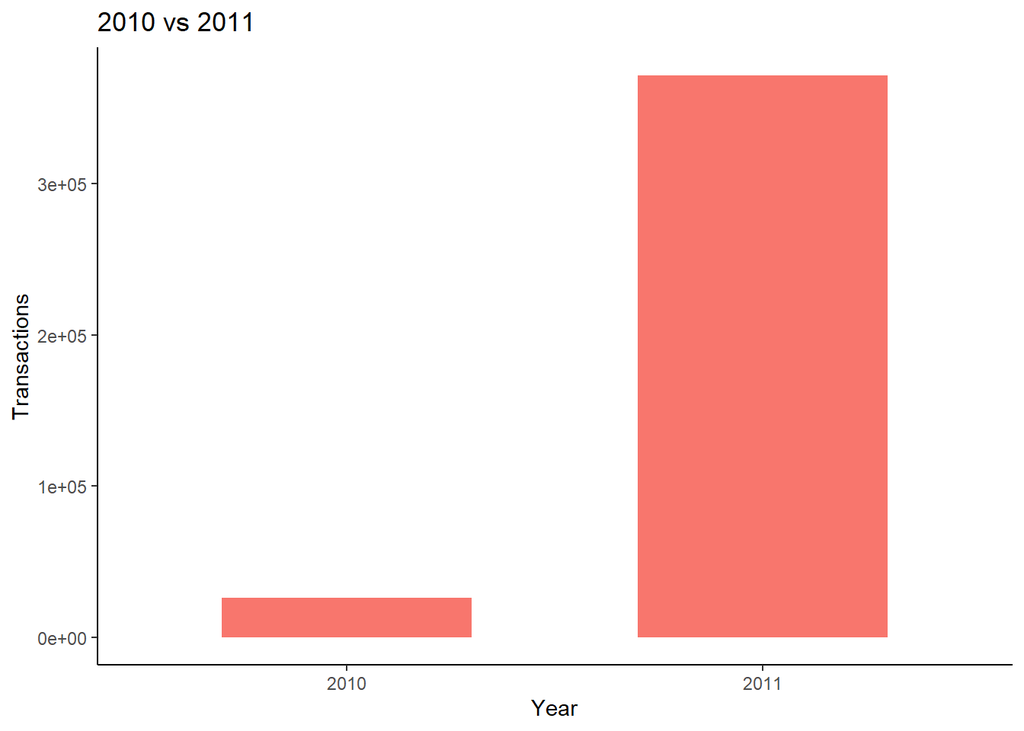

```r
ggplot(retail, aes(year)) + geom_bar(aes(fill = "year"), width = 0.6) + labs(title = "2010 vs 2011", x = "Year", y = "Transactions") + guides(fill = FALSE) + scale_x_discrete(labels = c("2010" = "2010", "2011" = "2011")) + theme_classic()
```

By comparing the total number of transactions in year 2010 and 2011, we find that people’s consumption habits changed a lot. People became interested in shopping online.

**Transactions By Country Analysis**

```r
Transactions_per_Country <- top_n(arrange(summarise(group_by(retail, Country), 'Number of Transcations' = n()), desc(`Number of Transcations`)), 10)
```

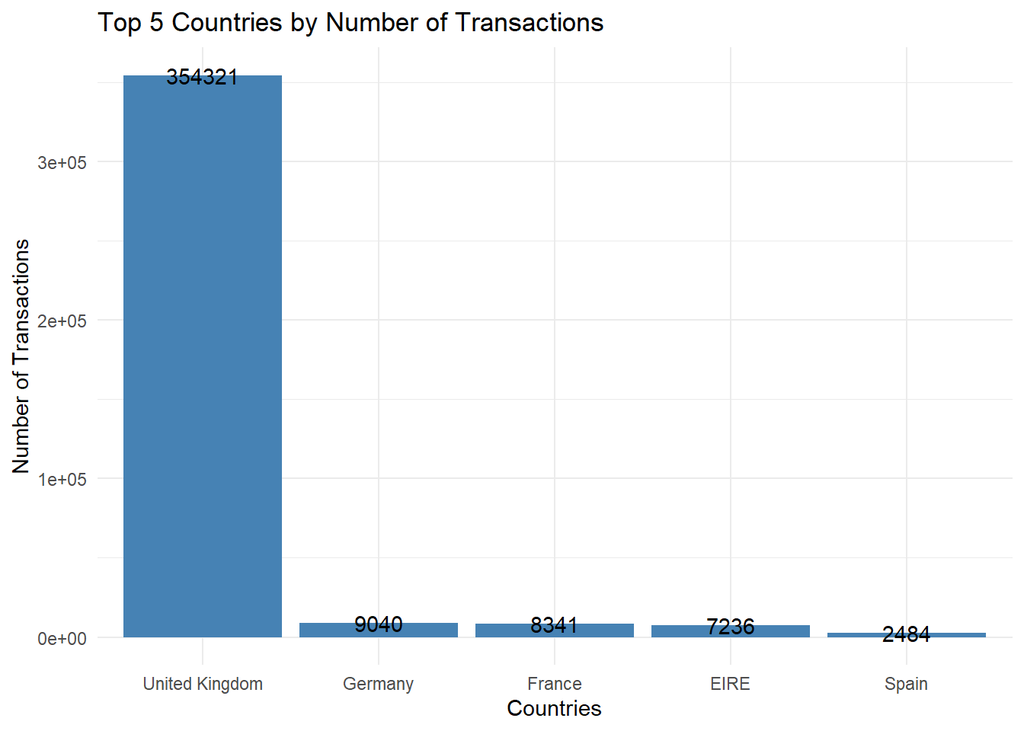

```r
names(Transactions_per_Country) <- c("Country", "Number of Transactions")

Transaction_per_Country_plot <- ggplot(head(Transactions_per_Country,5), aes(x = reorder(Country,-`Number of Transactions`), y = `Number of Transactions`)) + geom_bar(stat = 'identity', fill = "Steel Blue") +
  geom_text(aes(label = `Number of Transactions`)) +
  ggtitle('Top 5 Countries by Number of Transactions') + xlab('Countries') +
  ylab('Number of Transactions') +
  theme_minimal()
print(Transaction_per_Country_plot)
```

The above graphs displays that UK has the major portion of the customers with respect to other countries. Though Germany, Francec,EIRE and Spain ranked top 5, the number of transactions of these countries were far less than UK’s.

**Revenue By day of the week Analysis**

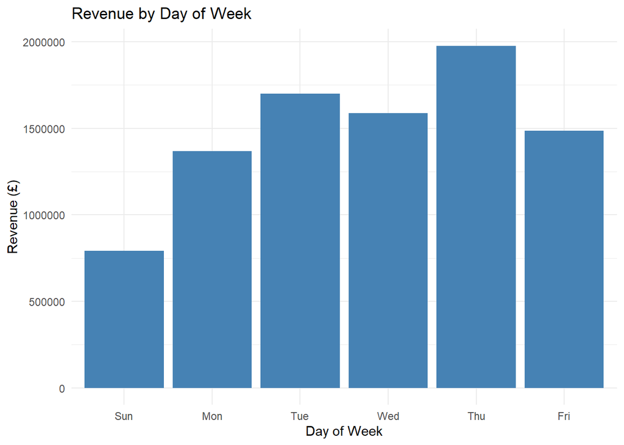

```r
ggplot(summarise(group_by(retail, dayOfWeek), revenue = sum(TotalSales)), aes(x = dayOfWeek, y = revenue)) + geom_bar(stat = 'identity', fill = 'Steel Blue') + labs(x = 'Day of Week', y = 'Revenue (£)', title = 'Revenue by Day of Week') +
  theme_minimal()
```

The above graph shows that Tuesday and Thursday are the days where more revenue were generated in comparison to other weekdays. Saturday seems to be off for orders.

**Revenue By month of the year Analysis**

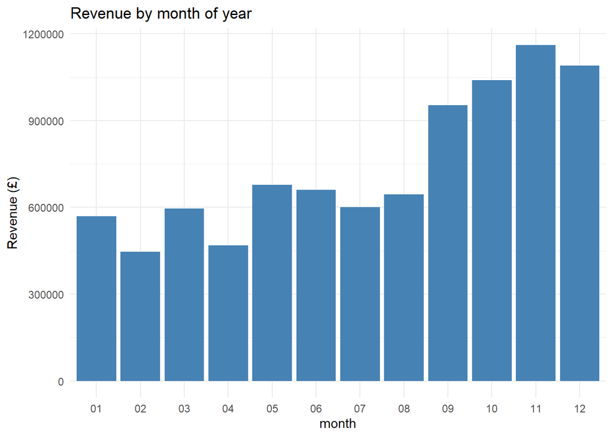

```r
ggplot(summarise(group_by(retail, month), revenue = sum(TotalSales)), aes(x = month, y = revenue)) + geom_bar(stat = 'identity', fill = 'Steel Blue') + labs(x = 'month', y = 'Revenue (£)', title = 'Revenue by month of year') +
  theme_minimal()
```

The perfect idea we get due to busy delivery system at the time of holidays, people tend to order in November for most of the holidays. The steep increase in sales in November can also be due to the sale season. Special sale for holidays is always considered as one of the best ideas.

**Transactions By hour of the Day Analysis**

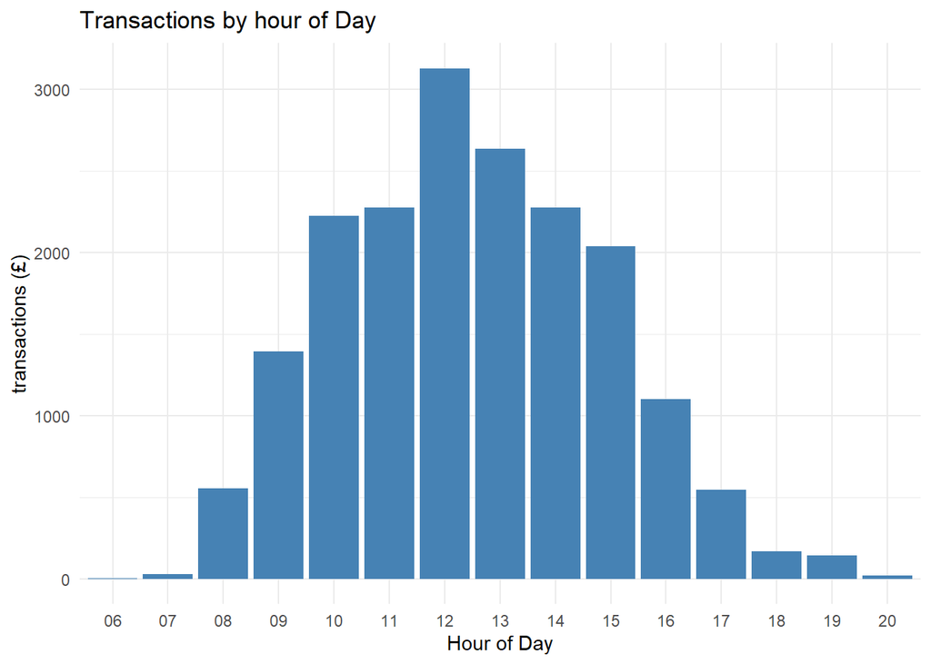

```r
ggplot(summarise(group_by(retail, hourOfDay), transactions = n_distinct(InvoiceNo)), aes(x = hourOfDay, y = transactions)) + geom_bar(stat = 'identity', fill = "Steel Blue") + labs(x = 'Hour of Day', y = 'transactions (£)', title = 'Transactions by hour of Day') +
  theme_minimal()
```

The above graph explains that between 10am till 3pm most of the orders are placed online.

## K-Means Clustering

#### Scaling the data

```r
RFM <- data.frame(RFM)
row.names(RFM) <- RFM$CustomerID
RFM <- RFM[,-1]
RFM_scaled <- scale(RFM)
RFM_scaled <- data.frame(RFM_scaled)
```

#### Determining Optimal Cluster

We will use two most popular methods to find an optimal number of clusters:

- Elbow Method
- Silhouette Method

**1. Elbow Method**

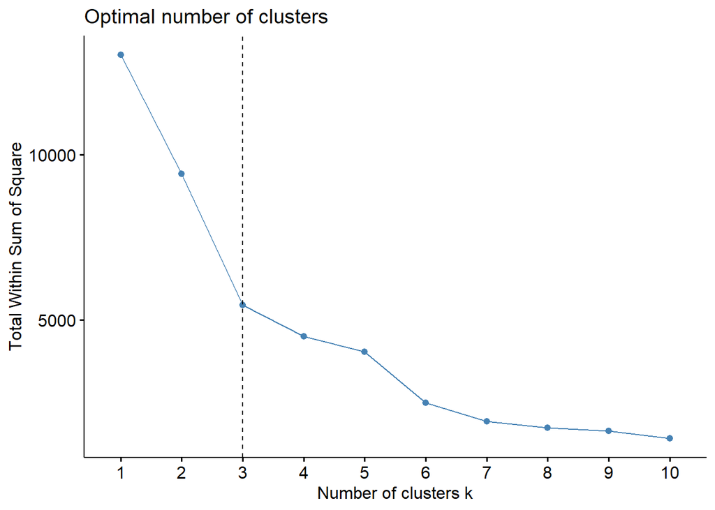

```r
fviz_nbclust(RFM_scaled, kmeans, method = "wss") + geom_vline(xintercept = 3, linetype = 2)
```

The graph starts to bend at Cluster 3, hence we can determine that K=3 is the Optimal Cluster.

**2. Average Silhoute Method**

In short, the average silhouette approach measures the quality of a clustering. That is, it determines how well each object lies within its cluster. A high average silhouette width indicates a good clustering. The average silhouette method computes the average silhouette of observations for different values of k. The optimal number of clusters k is the one that maximizes the average silhouette over a range of possible values for k Square.

We can use the silhouette function in the cluster package to compuate the average silhouette width. The following code computes this approach for 1-10 clusters.

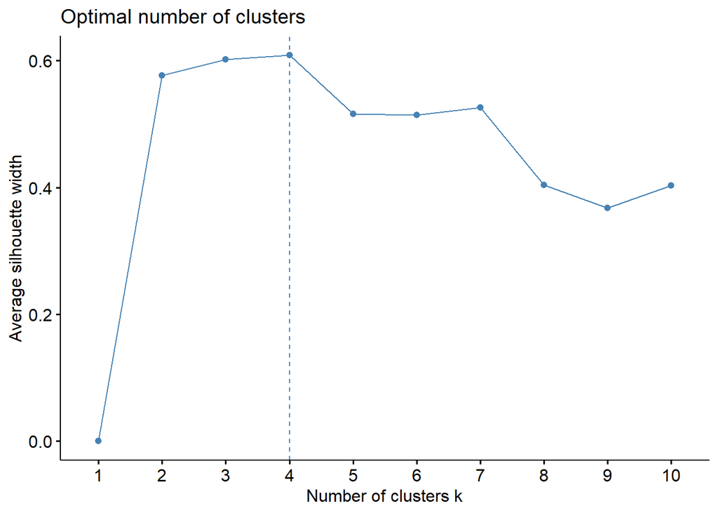

```r
fviz_nbclust(RFM_scaled, kmeans, method = "silhouette")
```

From above graph we can visualize that k=4 is the Optimal number of Cluster and k=3 is the next best.

We will visualize kmeans clusters using both k=3 and k=4 for better understanding.

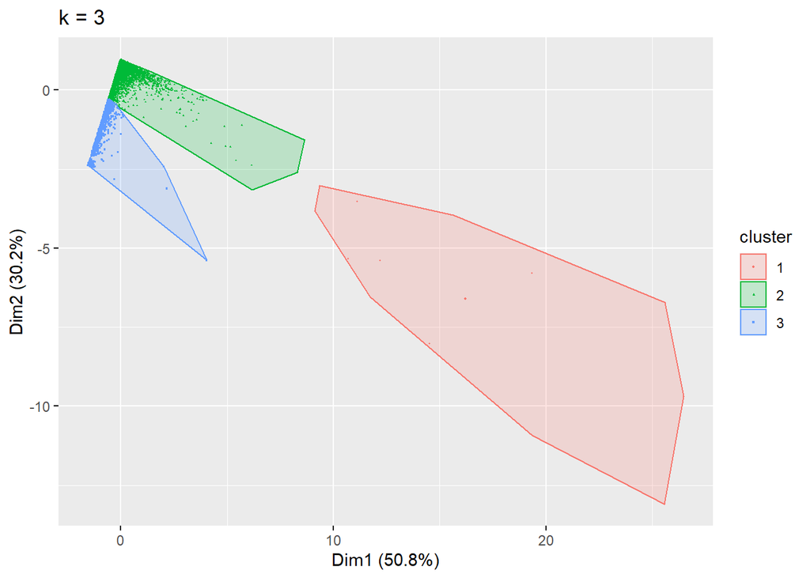

```r
k3 <- kmeans(RFM_scaled, centers = 3, nstart = 25)
k4 <- kmeans(RFM_scaled, centers = 4, nstart = 25)

fviz_cluster(k3, geom = "point", data = RFM_scaled, pointsize = 0.2) + ggtitle("k = 3")
```

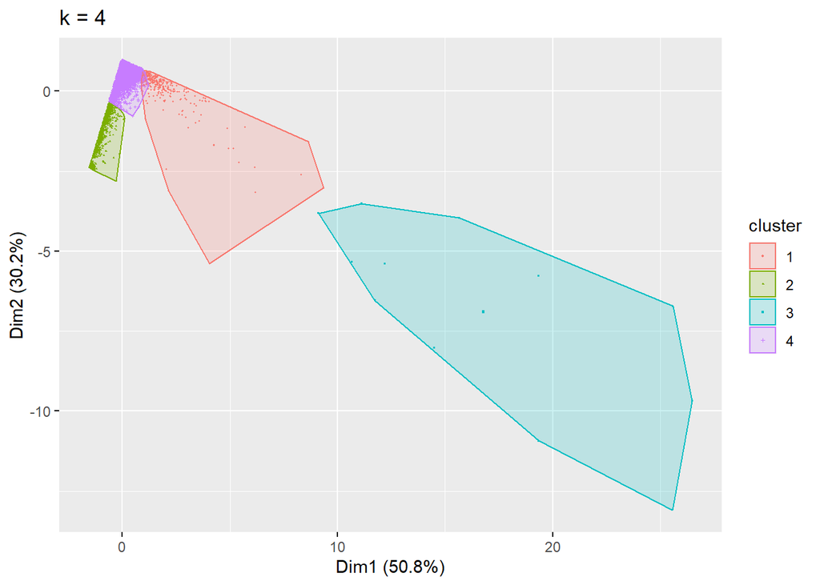

```r
fviz_cluster(k4, geom = "point", data = RFM_scaled, pointsize = 0.2) + ggtitle("k = 4")
```

We see that there are some overlapping of clusters for k=4, hence we confirm that k=3 is the best and optimal k.

After Comparing the above algorithms we have decided that K=3 is the optimal Cluster.

Here is the summary statistics of each cluster for each of the variables.

```r
res <- cbind(RFM, ClusterId = k3$cluster)
res <- as.data.frame(res)
```

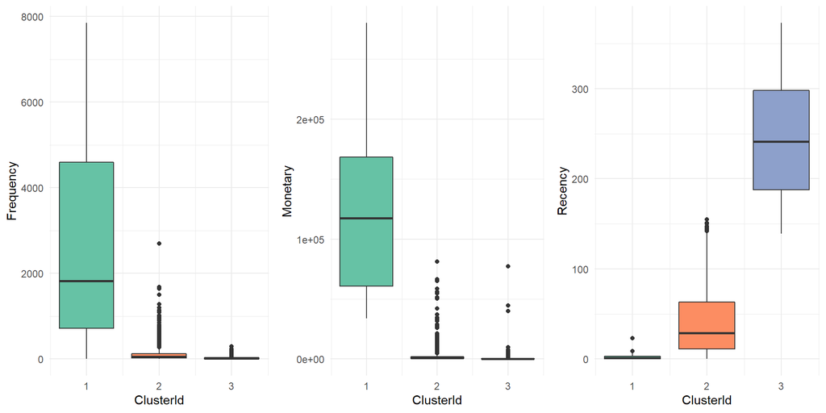

```r
a <- ggplot(res, aes(x = ClusterId, y = Frequency, group = ClusterId, fill = as.factor(ClusterId))) +
  geom_boxplot(show.legend = FALSE) + theme_minimal() + scale_fill_brewer(palette = "Set2")
b <- ggplot(res, aes(x = ClusterId, y = Monetary, group = ClusterId, fill = as.factor(ClusterId))) +
  geom_boxplot(show.legend = FALSE) + theme_minimal() + scale_fill_brewer(palette = "Set2")
c <- ggplot(res, aes(x = ClusterId, y = Recency, group = ClusterId, fill = as.factor(ClusterId))) +
  geom_boxplot(show.legend = FALSE) + theme_minimal() + scale_fill_brewer(palette = "Set2")
grid.arrange(a,b,c, ncol = 3)
```

## Hierarchical Clustering

Hierarchical clustering is an alternative approach to k-means clustering for identifying groups in the dataset. It does not require us to pre-specify the number of clusters to be generated as is required by the k-means approach. Furthermore, hierarchical clustering has an added advantage over K-means clustering in that it results in an attractive tree-based representation of the observations, called a dendrogram.

#### Determining Optimal Cluster

**1. Elbow Method**

To perform the elbow method, we just need to change the second argument in fviz_nbclust to FUN = hcut for hierarchical clustering.

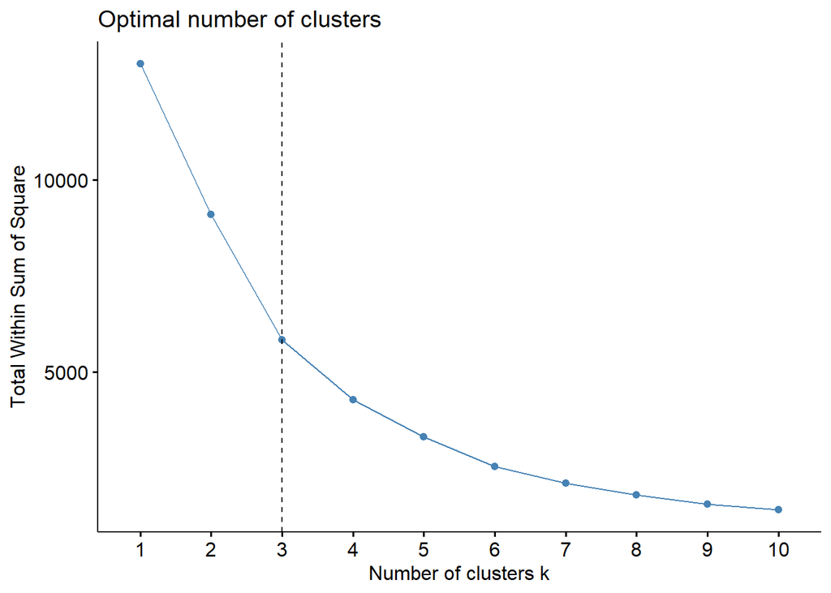

```r
fviz_nbclust(RFM_scaled, FUN = hcut, method = "wss") + geom_vline(xintercept = 3, linetype = 2)
```

**2. Average Silhouette Method**

To perform the average silhouette method we follow a similar process.

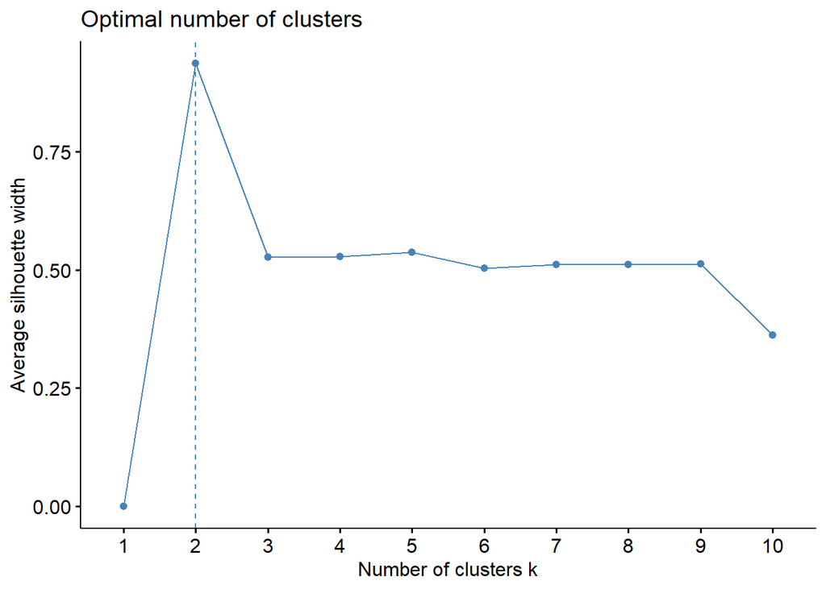

```r
fviz_nbclust(RFM_scaled, FUN = hcut, method = "silhouette")
```

**Hierarchical Clustering**

We can perform agglomerative HC with hclust. First we compute the dissimilarity values with dist and then feed these values into hclust and specify the agglomeration method to be used (i.e. “complete”, “average”, “single”, “ward.D”). We then plot the dendrogram.

```r
euclidian_dist <- dist(RFM_scaled, method = "euclidean")

# Hierarchical clustering using Complete Linkage
hc1 <- hclust(euclidian_dist, method = "single" )

hc2 <- hclust(euclidian_dist, method = "complete" )

hc3 <- hclust(euclidian_dist, method = "ward.D2" )

hc4 <- hclust(euclidian_dist, method = "average" )

m <- c( "average", "single", "complete", "ward")
names(m) <- c( "average", "single", "complete", "ward")

# function to compute coefficient
ac <- function(x) {
  agnes(RFM_scaled, method = x)$ac
}

map_dbl(m, ac)
```

```
##   average    single  complete      ward
## 0.9976872 0.9955580 0.9984517 0.9992894
```

The agnes$ac value gets the agglomerative coefficient, which measures the amount of clustering structure found (values closer to 1 suggest strong clustering structure). We see that all the four linkage methods are quite similar and close to 1, but Ward’s method gives the best result. Also, in general, Complete and Ward’s linkage are preferred over others.

To confirm, we visualize both the dendrograms - Complete and Ward’s.

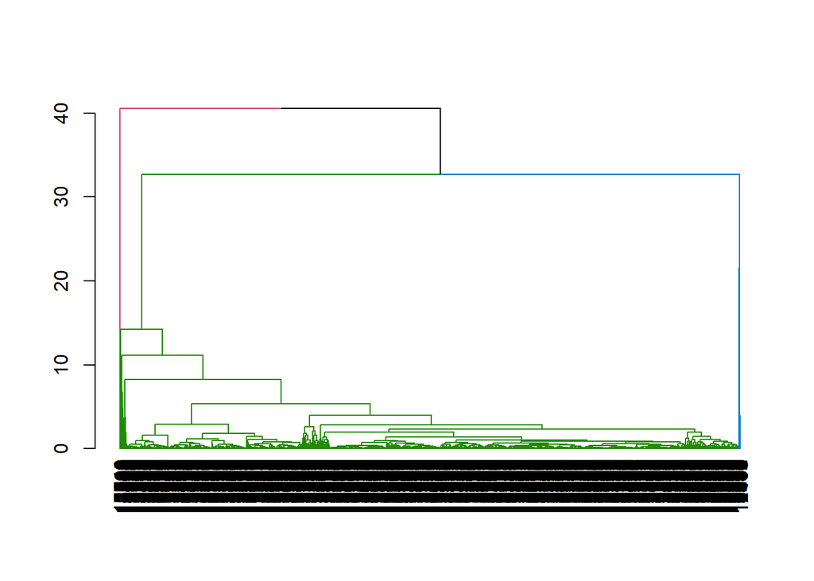

```r
hc2 <- as.dendrogram(hc2)
cd = color_branches(hc2,k = 3)
plot(cd)
```

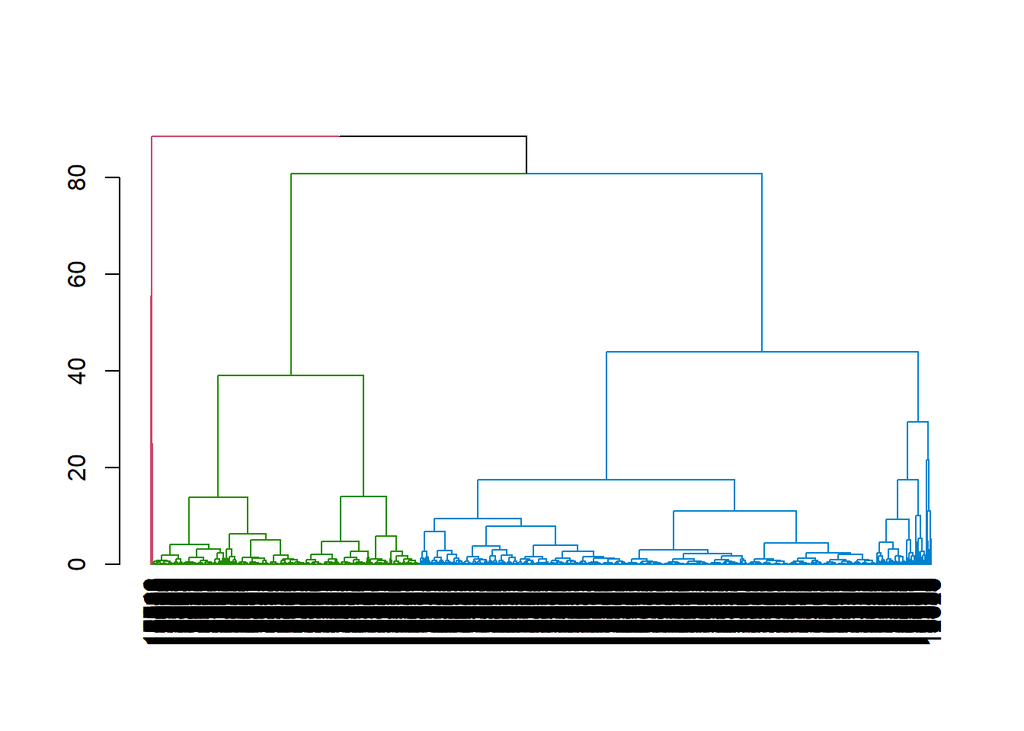

```r
hc3 <- as.dendrogram(hc3)
cd = color_branches(hc3,k = 3)
plot(cd)
```

We observe that the Complete linkage creates clusters for each outliers and thus creates 2 clusters each for 2 outlier which would not provide good result. We will go with Ward’s method.

Here is the summary statistics of each cluster for each of the variables.

```r
ward.clust = cutree(hc3,k = 3)
res1 <- cbind(RFM, ClusterId = ward.clust)
res1 <- as.data.frame(res1)
```

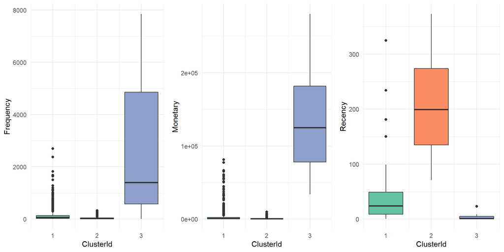

```r
a <- ggplot(res1, aes(x = ClusterId, y = Frequency, group = ClusterId, fill = as.factor(ClusterId))) +
  geom_boxplot(show.legend = FALSE) + theme_minimal() + scale_fill_brewer(palette = "Set2")
b <- ggplot(res1, aes(x = ClusterId, y = Monetary, group = ClusterId, fill = as.factor(ClusterId))) +
  geom_boxplot(show.legend = FALSE) + theme_minimal() + scale_fill_brewer(palette = "Set2")
c <- ggplot(res1, aes(x = ClusterId, y = Recency, group = ClusterId, fill = as.factor(ClusterId))) +
  geom_boxplot(show.legend = FALSE) + theme_minimal() + scale_fill_brewer(palette = "Set2")
grid.arrange(a,b,c, ncol = 3)
```

## Conclusions

Although both the methods did not give too good results, but k-means Clustering provided better results for this dataset.

To confirm that k-means is better, we do Dunn’s Index test.

```r
dunn_km = dunn(clusters = k3$cluster, Data = RFM_scaled)
dunn_km
```

```
## [1] 0.0006127461
```

```r
memb_ward = cutree(hc3, k = 3)
dunn_ward <- dunn(clusters = memb_ward, Data = RFM_scaled)
dunn_ward
```

```
## [1] 0.0005361066
```

We see that the Dunn’s Index for k-means is higher than hierarchical clustering indicating K-means gives better Clustering results.

```r
sil_k3 <- silhouette(k3$cluster, euclidian_dist)
summary(sil_k3)
```

```
## Silhouette of 4338 units in 3 clusters from silhouette.default(x = k3$cluster, dist = euclidian_dist) :
##  Cluster sizes and average silhouette widths:
##         13       3245       1080
## 0.08538752 0.60801119 0.59006709
## Individual silhouette widths:
##    Min. 1st Qu.  Median    Mean 3rd Qu.    Max.
## -0.3244  0.5575  0.6753  0.6020  0.7148  0.7392
```

```r
sil_hc <- silhouette(memb_ward, euclidian_dist)
summary(sil_hc)
```

```
## Silhouette of 4338 units in 3 clusters from silhouette.default(x = memb_ward, dist = euclidian_dist) :
##  Cluster sizes and average silhouette widths:
##      2843      1484        11
## 0.5929253 0.4035285 0.1143834
## Individual silhouette widths:
##    Min. 1st Qu.  Median    Mean 3rd Qu.    Max.
## -0.4934  0.4916  0.6108  0.5269  0.6633  0.7080
```

The Silhouette Width (mean of all silhouette values) is higher for K-means than Hierarchical Clustering which confirms that the k-means cluster yields better results for this dataset.

```r
table(k3$cluster)
```

```
##
##    1    2    3
##   13 3245 1080
```

```r
table(ward.clust)
```

```
## ward.clust
##    1    2    3
## 2843 1484   11
```

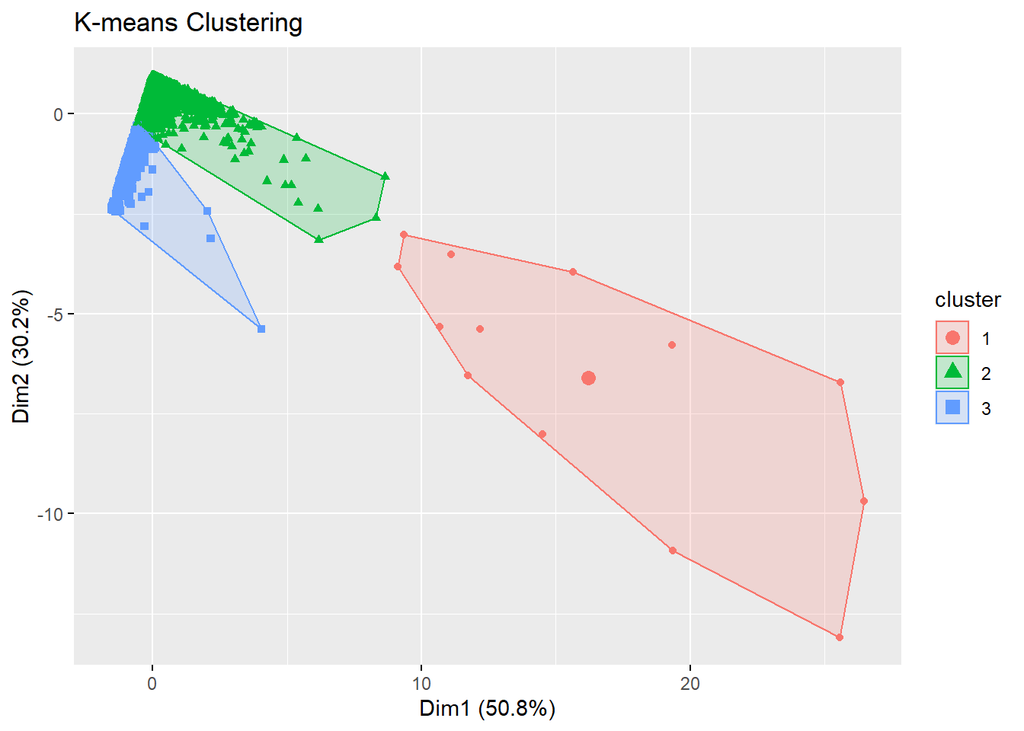

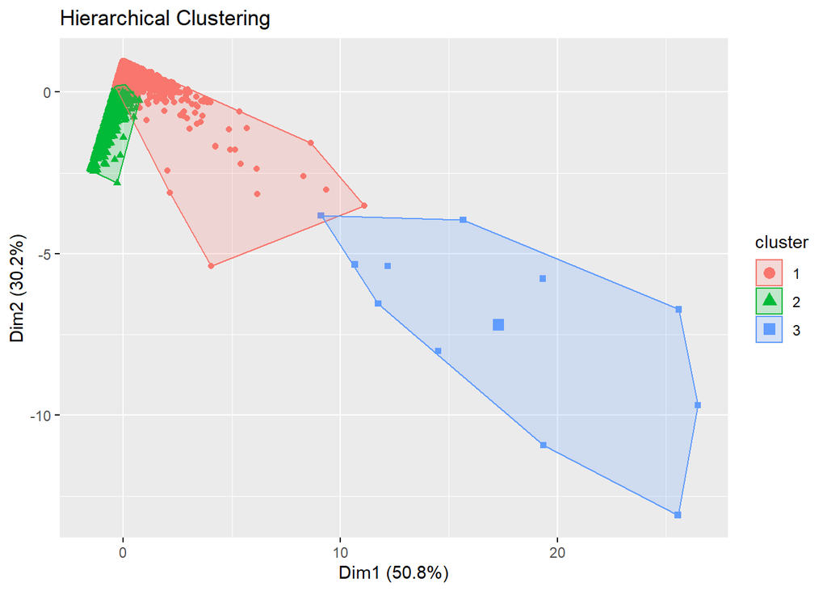

```r
fviz_cluster(k3, data = RFM_scaled, geom = "point") + ggtitle("K-means Clustering")
fviz_cluster(list(data = RFM_scaled, cluster = ward.clust), geom = "point") + ggtitle("Hierarchical Clustering")
```

We see there are some overlapping for Hierarchical clusters, therefore, we choose K-means clusters as our final clusters.

```r
#K-means Clustering results
aggregate(res,by = list(res$ClusterId),FUN = mean)
```

```
##   Group.1  Frequency    Monetary    Recency ClusterId
## 1       1 2565.30769 126118.3100   3.692308         1
## 2       2  103.08906   2028.8339  40.377196         2
## 3       3   27.78796    637.3185 246.308333         3
```

```r
#Hierarchical clustering results
aggregate(res1,by = list(res1$ClusterId),FUN = mean)
```

```
##   Group.1  Frequency    Monetary    Recency ClusterId
## 1       1  112.33978   2277.6918  30.464298         1
## 2       2   33.25472    617.2412 209.183962         2
## 3       3 2650.18182 138176.7545   4.181818         3
```

**Inferences:**

**K-Means Clustering with 3 Clusters**

- Customers in Cluster 1 are the customers with high amount of transactions, are frequent buyers, and recent buyers as compared to other customers, hence most important from business point of view.
- Customers in Cluster 2 are the customers with average amount of transactions as compared to other customers.
- Customers in Cluster 3 are the customers with least amount of transactions, are infrequent buyers, and not recent buyers and hence least of importance from business point of view.

**Hierarchical Clustering with 3 Clusters**

- Customers in Cluster 1 are the customers with average amount of transactions as compared to other customers.
- Customers in Cluster 2 are the customers with least amount of transactions, are infrequent buyers, and not recent buyers and hence least of importance from business point of view.
- Customers in Cluster 3 are the customers with high amount of transactions, are frequent buyers, and recent buyers as compared to other customers, hence most important from business point of view.